# Qualidade de Vinhos Tintos e Brancos

Análise exploratória de dados por Daniel Senna Panizzo

9 de agosto de 2017

### 1. RESUMO

Este relatório irá explorar 11 propriedades químicas de um conjunto de 3.000 variantes do “Vinho Verde” Português, sendo 1.500 vinhos tintos e 1.500 vinhos brancos. Este conjunto de vinhos foi avaliado por, pelo menos, três especialistas que forneceram notas entre 0 (Ruim) e 10 (Excelente) para cada vinho. O intuito deste projeto é avaliar quais destas propriedades químicas influenciam na qualidade dos vinhos.

#### 1.1 Carga do conjunto de dados

```
## 'data.frame':    3000 obs. of  15 variables:
##  $ X                   : int  1 2 3 4 5 6 7 8 9 10 ...
##  $ fixed.acidity       : num  7.4 7.8 7.8 11.2 7.4 7.4 7.9 7.3 7.8 7.5 ...
##  $ volatile.acidity    : num  0.7 0.88 0.76 0.28 0.7 0.66 0.6 0.65 0.58 0.5 ...
##  $ citric.acid         : num  0 0 0.04 0.56 0 0 0.06 0 0.02 0.36 ...
##  $ residual.sugar      : num  1.9 2.6 2.3 1.9 1.9 1.8 1.6 1.2 2 6.1 ...
##  $ chlorides           : num  0.076 0.098 0.092 0.075 0.076 0.075 0.069 0.065 0.073 0.071 ...
##  $ free.sulfur.dioxide : num  11 25 15 17 11 13 15 15 9 17 ...
##  $ total.sulfur.dioxide: num  34 67 54 60 34 40 59 21 18 102 ...
##  $ density             : num  0.998 0.997 0.997 0.998 0.998 ...
##  $ pH                  : num  3.51 3.2 3.26 3.16 3.51 3.51 3.3 3.39 3.36 3.35 ...
##  $ sulphates           : num  0.56 0.68 0.65 0.58 0.56 0.56 0.46 0.47 0.57 0.8 ...
##  $ alcohol             : num  9.4 9.8 9.8 9.8 9.4 9.4 9.4 10 9.5 10.5 ...
##  $ quality             : int  5 5 5 6 5 5 5 7 7 5 ...
##  $ type                : Factor w/ 2 levels "Red","White": 1 1 1 1 1 1 1 1 1 1 ...
##  $ quality.bucket      : Factor w/ 3 levels "Low","Medium",..: 2 2 2 2 2 2 2 3 3 2 ...
```

#### 1.2 Estatísticas descritivas do conjunto de dados

```
##        X          fixed.acidity    volatile.acidity  citric.acid
##  Min.   :   1.0   Min.   : 4.200   Min.   :0.0850   Min.   :0.0000
##  1st Qu.: 609.8   1st Qu.: 6.600   1st Qu.:0.2600   1st Qu.:0.2100
##  Median :1202.5   Median : 7.200   Median :0.3600   Median :0.3000
##  Mean   :1622.1   Mean   : 7.575   Mean   :0.4047   Mean   :0.3027
##  3rd Qu.:2450.2   3rd Qu.: 8.200   3rd Qu.:0.5400   3rd Qu.:0.4000
##  Max.   :4895.0   Max.   :15.900   Max.   :1.5800   Max.   :1.0000
##  residual.sugar     chlorides       free.sulfur.dioxide
##  Min.   : 0.600   Min.   :0.01200   Min.   :  1.00
##  1st Qu.: 1.900   1st Qu.:0.04300   1st Qu.: 12.00
##  Median : 2.400   Median :0.05900   Median : 23.00
##  Mean   : 4.506   Mean   :0.06709   Mean   : 25.52
##  3rd Qu.: 6.100   3rd Qu.:0.08000   3rd Qu.: 35.00
##  Max.   :65.800   Max.   :0.61100   Max.   :289.00
##  total.sulfur.dioxide    density             pH          sulphates
##  Min.   :  6.00       Min.   :0.9874   Min.   :2.740   Min.   :0.2500
##  1st Qu.: 37.75       1st Qu.:0.9935   1st Qu.:3.140   1st Qu.:0.4700
##  Median : 91.00       Median :0.9958   Median :3.240   Median :0.5500
##  Mean   : 92.57       Mean   :0.9954   Mean   :3.252   Mean   :0.5743
##  3rd Qu.:138.00       3rd Qu.:0.9974   3rd Qu.:3.360   3rd Qu.:0.6500
##  Max.   :440.00       Max.   :1.0390   Max.   :4.010   Max.   :2.0000
##     alcohol         quality         type      quality.bucket
##  Min.   : 8.40   Min.   :3.000   Red  :1500   Low   : 114
##  1st Qu.: 9.50   1st Qu.:5.000   White:1500   Medium:2368
##  Median :10.20   Median :6.000                High  : 518
##  Mean   :10.44   Mean   :5.743
##  3rd Qu.:11.20   3rd Qu.:6.000
##  Max.   :14.90   Max.   :9.000
```

### 2. SEÇÃO DE GRÁFICOS UNIVARIADOS

#### 2.1 Qualidade

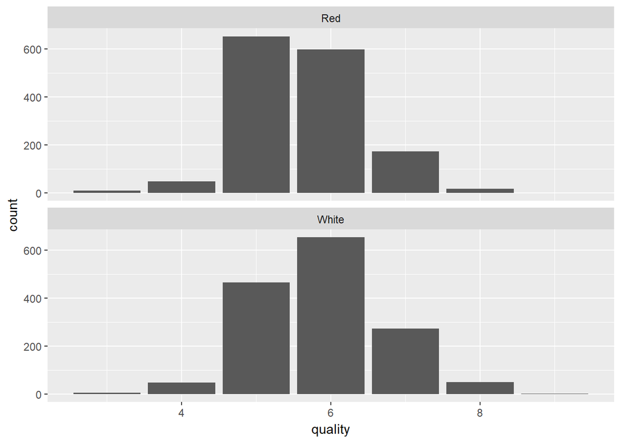

```
## ws$type: Red
##    Min. 1st Qu.  Median    Mean 3rd Qu.    Max.
##   3.000   5.000   6.000   5.621   6.000   8.000
## --------------------------------------------------------
## ws$type: White
##    Min. 1st Qu.  Median    Mean 3rd Qu.    Max.
##   3.000   5.000   6.000   5.866   6.000   9.000
```

A distribuição da qualidade dos vinhos é semalhantes entre os tintos e brancos. Nesta amostra, não foram encontradas avaliações menores que 3 ou maiores que 9. Do total de vinhos, 3,8% foram avaliados com notas baixas (abaixo de 5), 78,9% foram avaliados com notas médias (5 e 6) e 17,3% foram avaliados com notas altas (acima de 6).

#### 2.2 Acidez Fixa

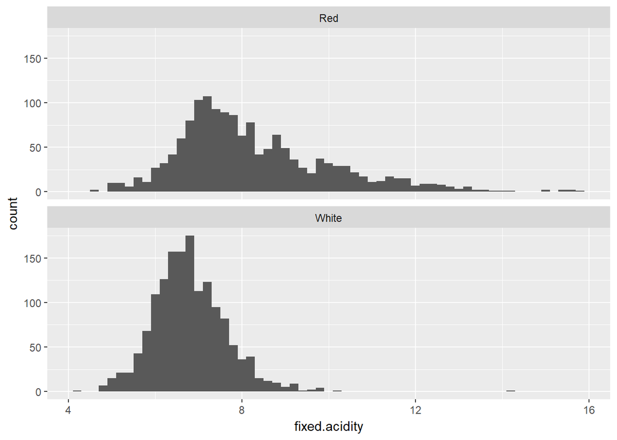

```
## ws$type: Red
##    Min. 1st Qu.  Median    Mean 3rd Qu.    Max.
##    4.60    7.10    7.90    8.31    9.20   15.90
## --------------------------------------------------------
## ws$type: White
##    Min. 1st Qu.  Median    Mean 3rd Qu.    Max.
##    4.20    6.30    6.80    6.84    7.30   14.20
```

A acidez fixa apresenta características distintas para cada tipo de vinho. Os vinhos tintos apresentam uma distribuição assimétrica positiva entre cerca de 4 e 16 g/dm³, com concentração entre 7 e 8 g/dm³. Os vinhos brancos apresentam uma distribuição normal entre cerca de 4 e 10 g/dm³, com concentração entre 6 e 7 g/dm³ e apresentando uma exceção ao redor de 14 g/dm³.

#### 2.3 Acidez Volátil

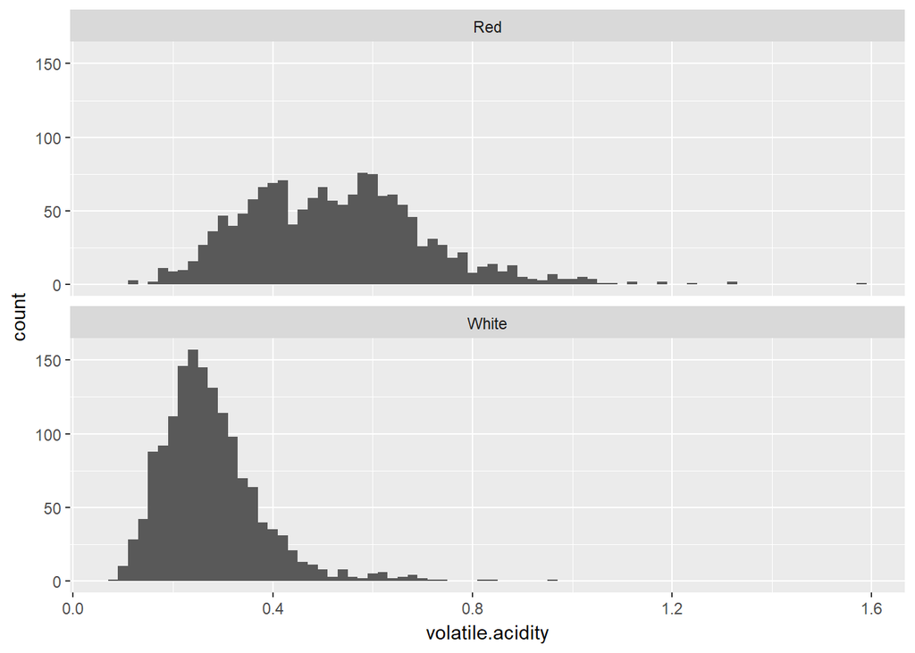

```
## ws$type: Red
##    Min. 1st Qu.  Median    Mean 3rd Qu.    Max.
##  0.1200  0.4000  0.5200  0.5292  0.6400  1.5800
## --------------------------------------------------------
## ws$type: White
##    Min. 1st Qu.  Median    Mean 3rd Qu.    Max.
##  0.0850  0.2200  0.2600  0.2801  0.3225  0.9650
```

A acidez volátil apresenta características distintas para cada tipo de vinho. Os vinhos tintos apresentam uma distribuição bimodal entre 0,1 e 1,6 g/dm³, com um pico em 0,4 g/dm³ e outro em 0,6 g/dm³. Os vinhos brancos apresentam uma leve distribuição assimétrica positiva entre 0,1 e 1,0 g/dm³, com concentração entre 0,15 e 0,3 g/dm³.

#### 2.4 Ácido Cítrico

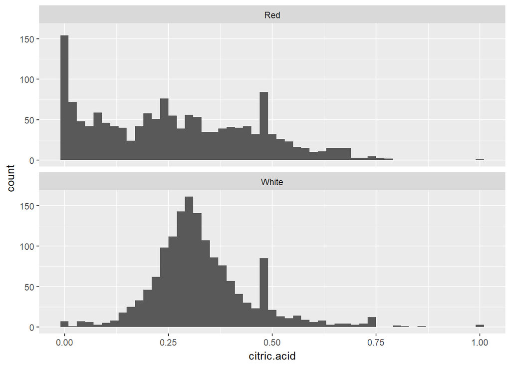

```
## ws$type: Red
##    Min. 1st Qu.  Median    Mean 3rd Qu.    Max.
##  0.0000  0.0975  0.2500  0.2698  0.4200  1.0000
## --------------------------------------------------------
## ws$type: White
##    Min. 1st Qu.  Median    Mean 3rd Qu.    Max.
##  0.0000  0.2600  0.3200  0.3355  0.3900  1.0000
```

O ácido cítrico apresenta características distintas para cada tipo de vinho. Os vinhos tintos apresentam uma distribuição multimodal, entre 0 g/dm³ e 1 g/dm³, com um pico em 0 g/dm³, outro em 0,24 g/dm³ e mais um em 0,48 g/dm³. Os vinhos brancos apresentariam uma distribuição normal se não fosse por um pico em 0,48 g/dm³, curiosamente o mesmo valor que um dos picos da distribuição multimodal dos vinhos tintos.

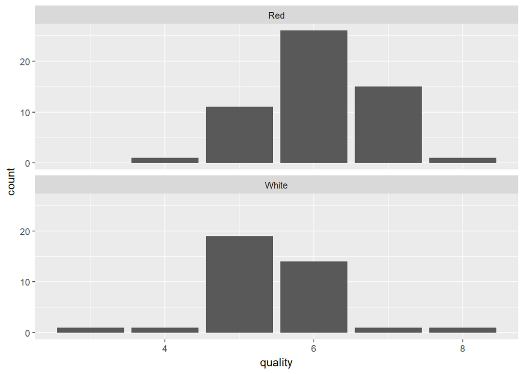

Investigando esta curiosidade, podemos observar que a distribuição da qualidade dos vinhos tintos com ácido cítrico entre 0,46 g/dm³ e 0,48 g/dm³ parace melhorar, mas aparentemente não afeta a distribuição da qualidade dos vinhos brancos.

#### 2.5 Açúcar Residual

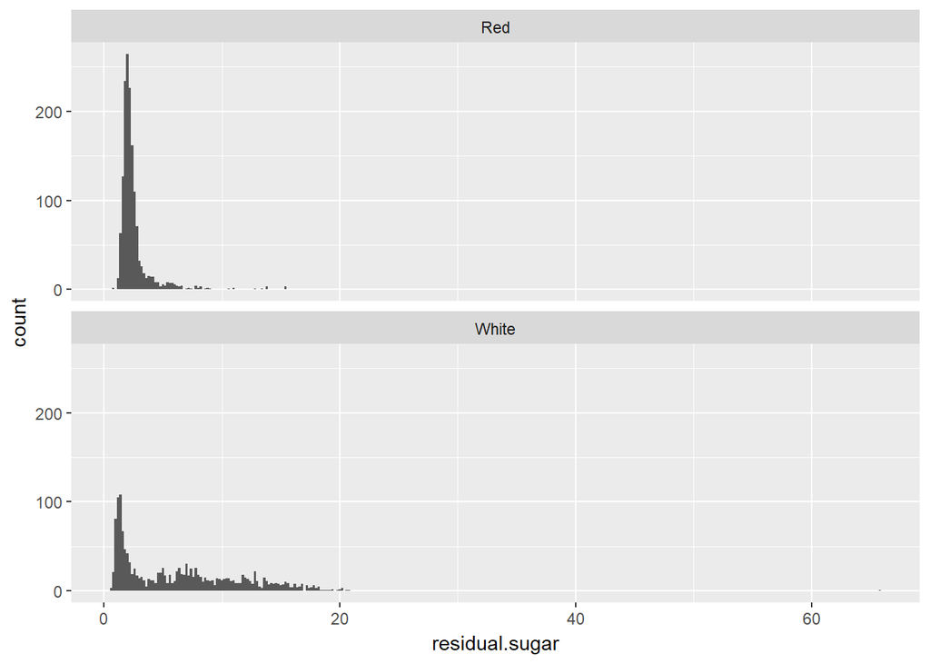

```
## ws$type: Red
##    Min. 1st Qu.  Median    Mean 3rd Qu.    Max.
##   0.900   1.900   2.200   2.535   2.600  15.500
## --------------------------------------------------------
## ws$type: White
##    Min. 1st Qu.  Median    Mean 3rd Qu.    Max.
##   0.600   1.700   5.500   6.478  10.012  65.800
```

O açucar residual apresenta uma exceção próxima de 70 g/dm³ que dificulta a análise do histograma. Para melhorar nossa visualização, omitiremos 1% dos vinhos com os maiores valores de açucar residual.

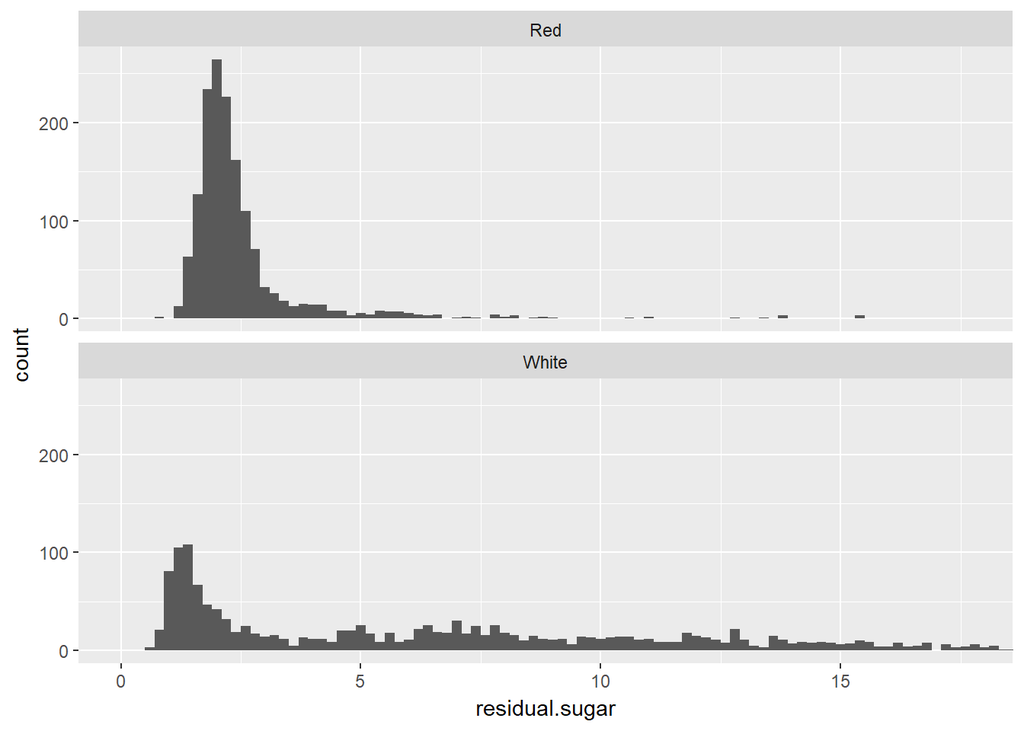

O açucar residual apresenta características distintas para cada tipo de vinho. Os vinhos tintos apresentam uma leve distribuição assimétrica positiva entre 1 e 15 g/dm³, com concentração entre 1,5 e 2,5 g/dm³. Os vinhos brancos apresentam uma distribuição assimétrica positiva e uma longa cauda, com concentração entre 1 g/dm³ e 1,5 dm³. No gráfico a seguir investigamos melhor a distribuição dos vinhos brancos utilizando a escala de log10 no eixo X.

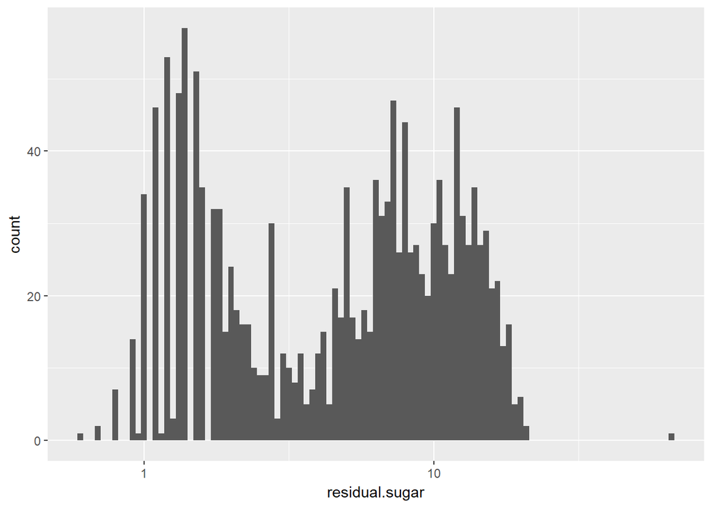

Nesta investigação em log 10, podemos observar melhor a distribuição bimodal do açúcar residual nos vinhos brancos, sendo um dos picos uma entre 1 e 3 e outro entre 8 e 12.

#### 2.6 Cloretos

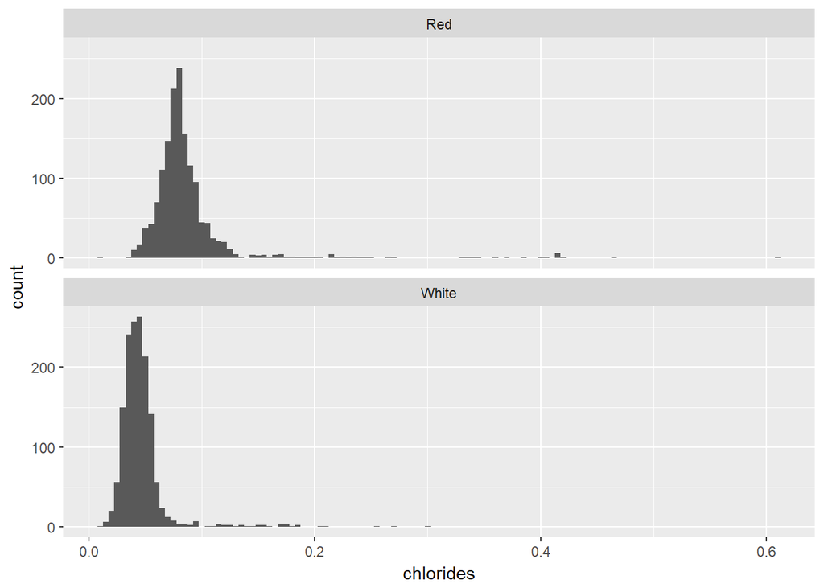

```
## ws$type: Red
##    Min. 1st Qu.  Median    Mean 3rd Qu.    Max.
## 0.01200 0.07100 0.08000 0.08825 0.09100 0.61100
## --------------------------------------------------------
## ws$type: White
##    Min. 1st Qu.  Median    Mean 3rd Qu.    Max.
## 0.01200 0.03600 0.04300 0.04592 0.05000 0.30100
```

Apesar de ambos os tipos de vinho apresentarem distribuição normal para o cloreto, os picos acontecem em valores distintos, sendo cerca de 0,08 g/dm³ para o vinho tinto e 0,04 g/dm³ para o vinho branco. Este último também apresentou uma distribuição mais densa.

Abaixo utilizamos o log10 no eixo x para para explorar a longa cauda dos dois tipos de vinho e observar melhor a distribuição das exceções. Podemos notar que ambos mantém uma distribuição semelhante à normal, no entanto, o pico da distribuição dos vinhos branco fica achatado.

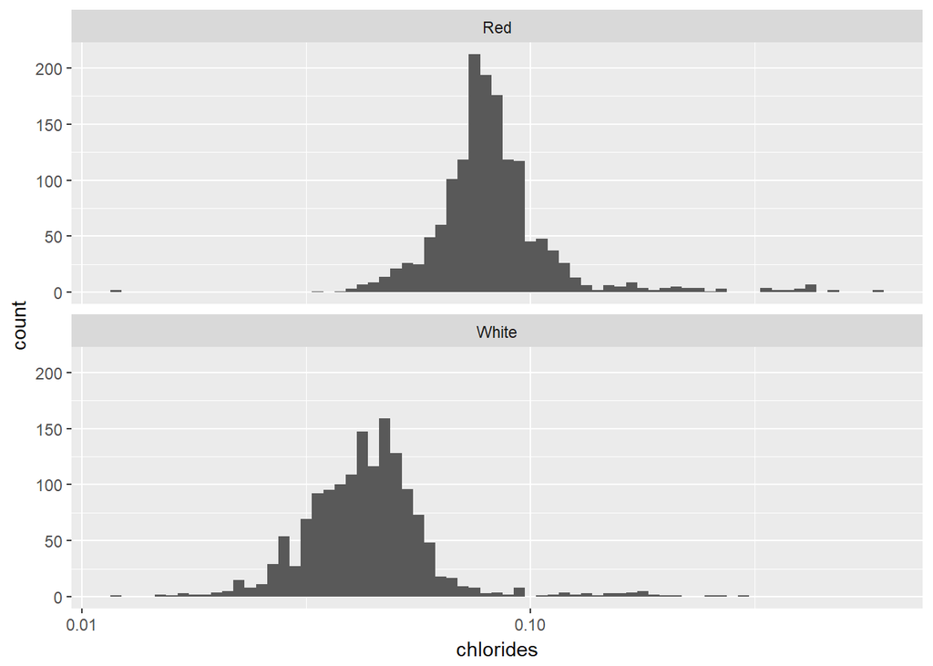

#### 2.7 Dióxido de Enxofre Livre

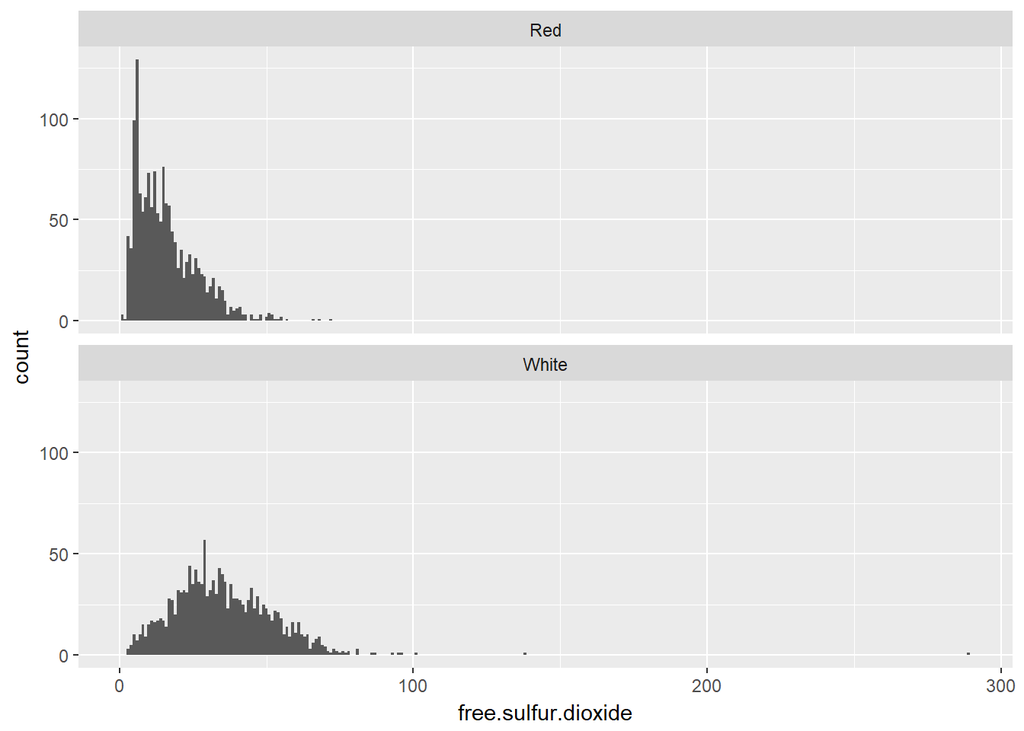

```
## ws$type: Red
##    Min. 1st Qu.  Median    Mean 3rd Qu.    Max.
##    1.00    8.00   14.00   15.87   21.00   72.00
## --------------------------------------------------------
## ws$type: White
##    Min. 1st Qu.  Median    Mean 3rd Qu.    Max.
##    3.00   24.00   33.00   35.17   46.00  289.00
```

O dióxido de enxofre livre apresenta características distintas para cada tipo de vinho. Os vinhos tintos apresentam uma distribuição assimétrica positiva entre 1 e 75 mg/dm³, com concentração entre 1 e 50 mg/dm³. Os vinhos brancos apresentam uma distribuição normal entre 1 e 150 mg/dm³, com concentração entre 20 e 40 mg/dm³.

#### 2.8 Dióxido de Enxofre Total

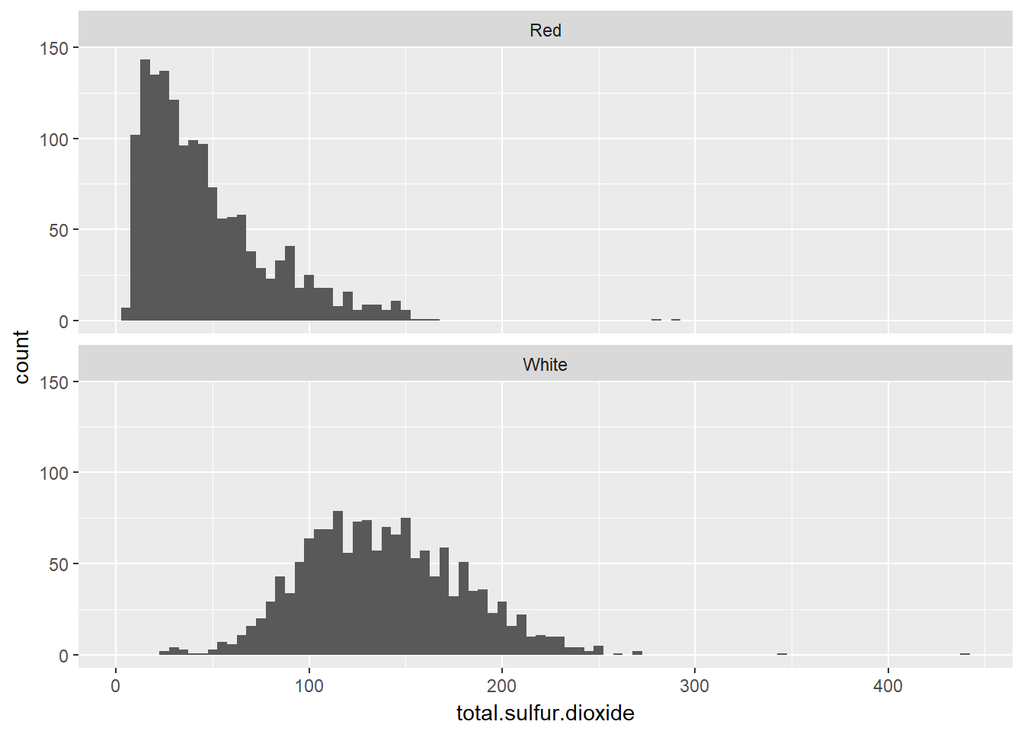

```
## ws$type: Red
##    Min. 1st Qu.  Median    Mean 3rd Qu.    Max.
##    6.00   22.00   38.00   46.72   63.00  289.00
## --------------------------------------------------------
## ws$type: White
##    Min. 1st Qu.  Median    Mean 3rd Qu.    Max.
##    24.0   108.0   135.0   138.4   166.0   440.0
```

Semelhante ao dióxido de enxofre livre, o dióxido de enxofre total apresenta características distintas para cada tipo de vinho. Os vinhos tintos apresentam uma distribuição assimétrica positiva entre 5 e 160 mg/dm³, com concentração entre 5 e 50 mg/dm³. Os vinhos brancos apresentam uma distribuição normal entre 25 e 275 mg/dm³, com concentração entre 90 e 160 mg/dm³.

#### 2.9 Densidade

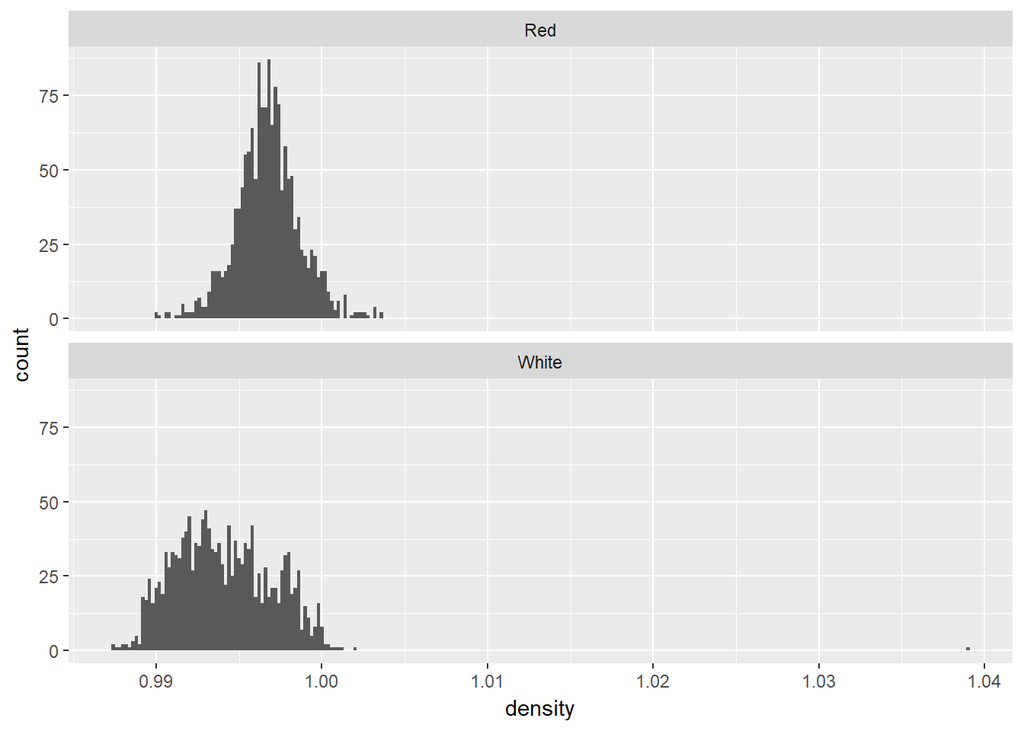

```
## ws$type: Red
##    Min. 1st Qu.  Median    Mean 3rd Qu.    Max.
##  0.9901  0.9956  0.9968  0.9968  0.9979  1.0037
## --------------------------------------------------------
## ws$type: White
##    Min. 1st Qu.  Median    Mean 3rd Qu.    Max.
##  0.9874  0.9918  0.9938  0.9941  0.9962  1.0390
```

Apesar de ambos os tipos de vinho apresentarem distribuição normal para a densidade, os picos acontecem em valores distintos. Como esta distribuição possui exceções com valores muito altos, omitiremos 1% dos vinhos com os maiores valores de densidade.

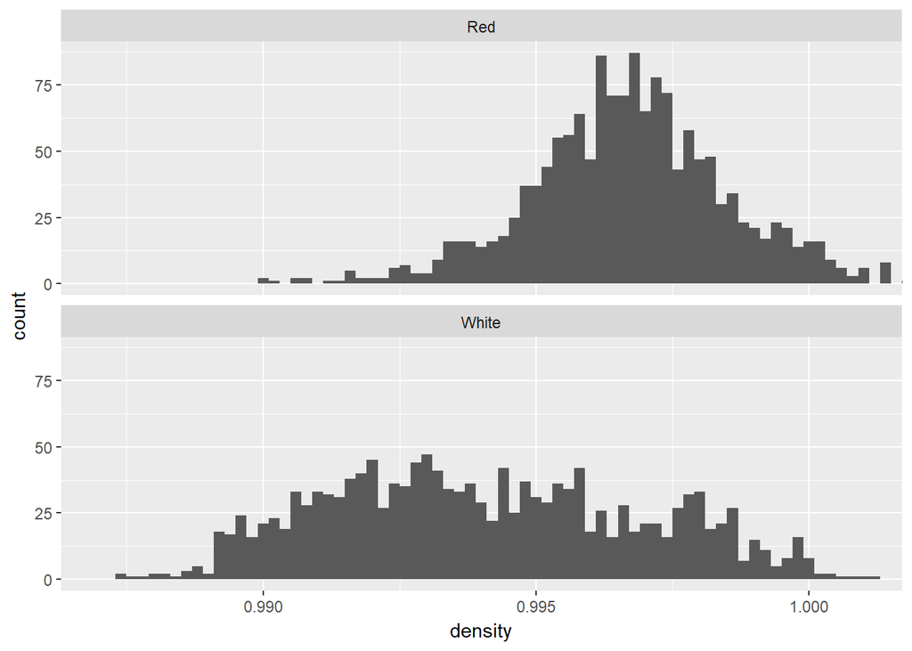

Observando mais de perto as distribuições, podemos identificar que a distribuição de densidade dos vinhos tintos está entre de 0,990 e 1,004 g/cm³, com concentração entre 0,995 g/cm³ e 0,998 g/cm³. Os vinhos brancos apresentam um distribuição pouco densa entre 0,987 e 1,003 g/cm³, com concentração entre 0,9925 e 0,9975 g/cm³.

#### 2.10 pH

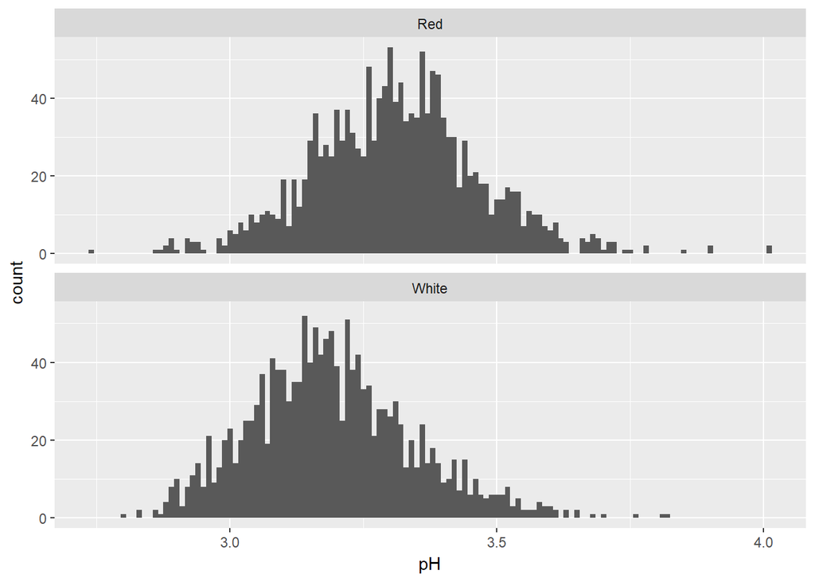

```
## ws$type: Red
##    Min. 1st Qu.  Median    Mean 3rd Qu.    Max.
##   2.740   3.210   3.310   3.312   3.400   4.010
## --------------------------------------------------------
## ws$type: White
##    Min. 1st Qu.  Median    Mean 3rd Qu.    Max.
##   2.800   3.090   3.180   3.191   3.280   3.820
```

Apesar de ambos os tipos de vinho apresentarem distribuição normal para o pH, os picos acontecem em valores distintos, sendo cerca de 3,3 para o vinho tinto e 3,2 para o vinho branco.

#### 2.11 Sulfatos

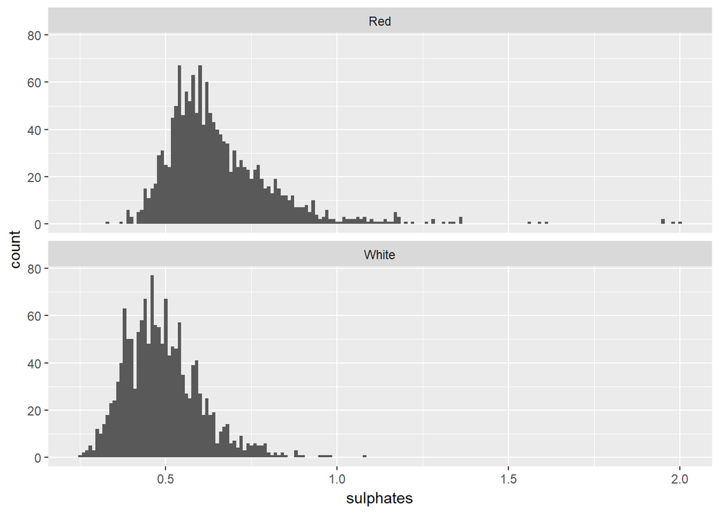

```
## ws$type: Red
##    Min. 1st Qu.  Median    Mean 3rd Qu.    Max.
##  0.3300  0.5500  0.6200  0.6570  0.7225  2.0000
## --------------------------------------------------------
## ws$type: White
##    Min. 1st Qu.  Median    Mean 3rd Qu.    Max.
##  0.2500  0.4100  0.4800  0.4916  0.5500  1.0800
```

#### 2.12 Álcool

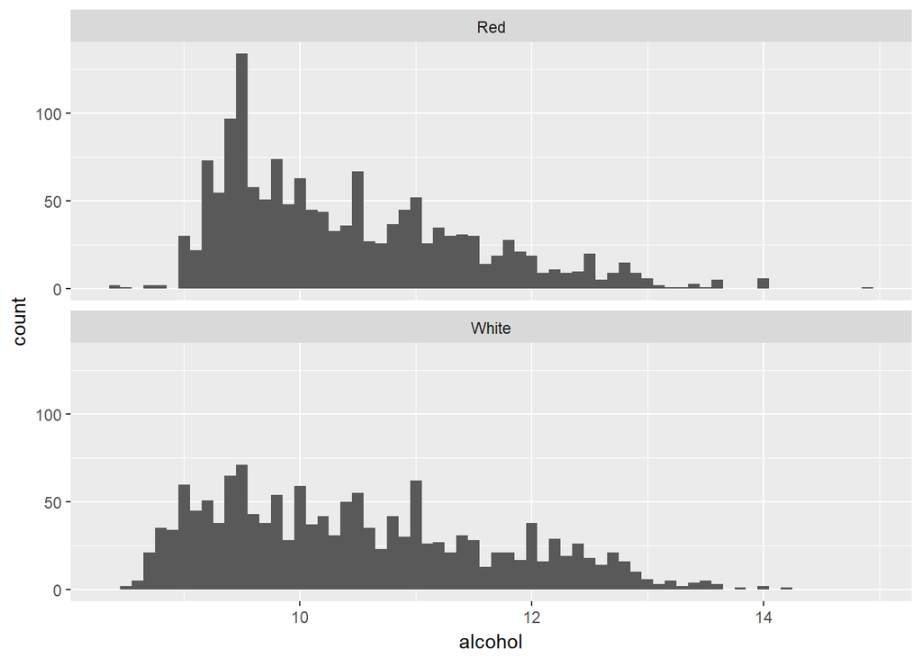

```
## ws$type: Red
##    Min. 1st Qu.  Median    Mean 3rd Qu.    Max.
##    8.40    9.50   10.10   10.40   11.07   14.90
## --------------------------------------------------------
## ws$type: White
##    Min. 1st Qu.  Median    Mean 3rd Qu.    Max.
##    8.50    9.50   10.30   10.49   11.30   14.20
```

### 3. ANÁLISE UNIVARIADA

#### 3.1 Qual a estrutura do conjunto de dados?

O conjunto de dados é composto por 3.000 variantes do “Vinho Verde” Português, sendo 1.500 vinhos tintos e 1.500 vinhos brancos, com medições de onze propriedades químicas:

- Acidez Fixa: ácido que contribui com a conservação do vinho.
- Acidez Volátil: quantidade de ácido acético no vinho, em níveis altos pode levar a um desagradável gosto de vinagre.
- Ácido Cítrico: encontrado em pequenas quantidades, pode adicionar “frescor” e sabor aos vinhos.
- Açúcar Residual: quantidade de açúcar remanescente após o fim da fermentação.
- Cloretos: quantidade de sal no vinho.
- Dióxido de Enxofre Livre: previne o aumento de micróbios e a oxidação do vinho.
- Dióxido de Enxofre Total: evidencia a aroma e gosto do vinho.
- Densidade: densidade da água, depende do percentual da álcool e quantidade de açúcar.
- pH: descreve o quão ácido ou básico é um vinho em uma escala de 0 a 14.
- Sulfatos: aditivo que age como antimocrobiano e antioxidante.
- Álcool: percentual de álcool presente no vinho.

E uma propriedade sensorial: - Qualidade: nota entre 0 e 10 conferida por especialistas.

Observações: - A maioria dos vinhos possuem qualidade média (notas 5 e 6); - A média de açúcar residual para vinhos tintos (2,53 g/dm³) é bem menor que a média para vinhos brancos (6,48 g/dm³); - A distribuição do percentual álcoolico é uma das poucas propriedades com distribuição semelhantes entre os dois tipos de vinho;

#### 3.2 Quais são os principais atributos de interesse deste conjunto de dados?

O principal atributo é a qualidade do vinho, nossa variável dependente.

#### 3.3 Quais outros atributos você acha que podem lhe auxiliar na investigação destes atributos de interesse?

Neste primeiro momento de análises univariadas, é difícil identificar uma variável independente que se relacione bem com a qualidade. Talvez as relações do álcool e o açucar residual com as demais propriedades possam ser um ponto de partida já que são propriedades inversamente proporcionais devido ao processo de fermentação do vinho.

#### 3.4 Você criou novas variáveis a partir dos atributos existentes no conjunto de dados?

Esta amostra de dados foi uma união entre dados de vinhos tintos e brancos, portanto, foi criada uma variável “type” para diferenciar os registros de cada uma. Também foi criada uma classificação para a qualidade, de baixa (notas abaixo de 5), média (notas 5 e 6) e alta (notas acima de 6).

#### 3.5 Dos atributos investigados, distribuições incomuns foram encontradas? Você aplicou aperações nos dados para limpá-los, ajustá-los ou mudar a forma dos dados? Se sim, por quê?

Algumas propriedades como açucar residual e densidade do vinho branco possuiam exceções com valores altíssimos, sendo necessário removê-los para melhorar a visualização da distribuição. Além disso, o açucar residual do vinho branco apresentou uma longa cauda em sua distribuição, sendo necessário utilizar o log10 para identificar uma distribuição bimodal.

O ácido cítrico apresentou uma curiosa concentração entre 0,46 g/dm³ e 0,48 g/dm³ que distoa do restante da distribuição, tanto para vinhos tintos quanto para vinhos brancos. Uma olhar rápido da qualidade dos vinhos nestes valores parace apontar que há melhoria nos vinhos tintos.

### 4. SEÇÃO DE GRÁFICOS BIVARIADOS

Entre as propriedades químicas do vinho tinto, as que apresentam maior correlação com a qualidade, pelo método de Pearson, são o álcool (r = 0,468) e a acidez volátil (r = -0,389).

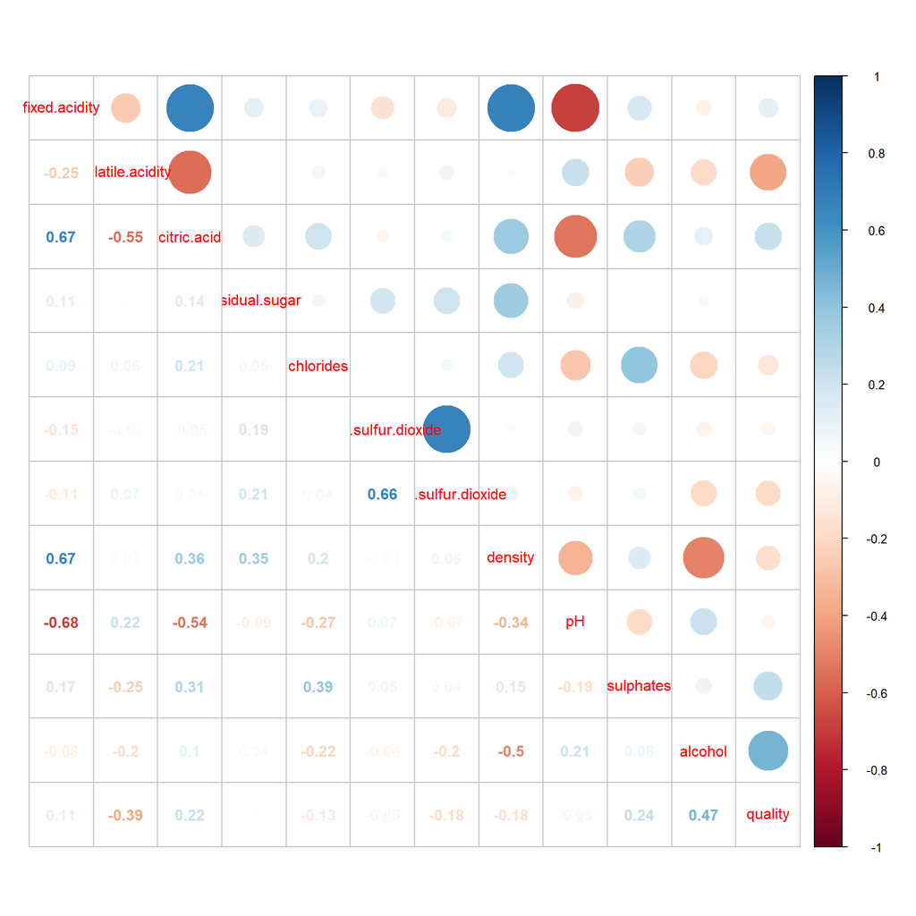

```
##                      fixed.acidity volatile.acidity citric.acid
## fixed.acidity           1.00000000     -0.250517293  0.66809067
## volatile.acidity       -0.25051729      1.000000000 -0.55103778
## citric.acid             0.66809067     -0.551037779  1.00000000
## residual.sugar          0.11072879     -0.001142033  0.14142057
## chlorides               0.09481302      0.058042657  0.20949086
## free.sulfur.dioxide    -0.15415695     -0.031354929 -0.05134153
## total.sulfur.dioxide   -0.11453589      0.065343296  0.03892319
## density                 0.67401373      0.020881634  0.36413606
## pH                     -0.68276624      0.224535813 -0.53913419
## sulphates               0.17447133     -0.248778175  0.30504375
## alcohol                -0.07569351     -0.197153087  0.10024659
## quality                 0.11304774     -0.389016730  0.22138437
##                      residual.sugar    chlorides free.sulfur.dioxide
## fixed.acidity           0.110728792  0.094813019        -0.154156952
## volatile.acidity       -0.001142033  0.058042657        -0.031354929
## citric.acid             0.141420571  0.209490862        -0.051341525
## residual.sugar          1.000000000  0.053062737         0.188738201
## chlorides               0.053062737  1.000000000         0.004919197
## free.sulfur.dioxide     0.188738201  0.004919197         1.000000000
## total.sulfur.dioxide    0.207889681  0.042344852         0.663636687
## density                 0.351271189  0.195932686        -0.028514838
## pH                     -0.088154220 -0.271088737         0.069177698
## sulphates              -0.001085461  0.393563872         0.054638847
## alcohol                 0.035539834 -0.219856888        -0.064432555
## quality                 0.002314170 -0.126225569        -0.052309603
##                      total.sulfur.dioxide     density          pH
## fixed.acidity                 -0.11453589  0.67401373 -0.68276624
## volatile.acidity               0.06534330  0.02088163  0.22453581
## citric.acid                    0.03892319  0.36413606 -0.53913419
## residual.sugar                 0.20788968  0.35127119 -0.08815422
## chlorides                      0.04234485  0.19593269 -0.27108874
## free.sulfur.dioxide            0.66363669 -0.02851484  0.06917770
## total.sulfur.dioxide           1.00000000  0.06108131 -0.06606682
## density                        0.06108131  1.00000000 -0.34220685
## pH                            -0.06606682 -0.34220685  1.00000000
## sulphates                      0.04103213  0.14941517 -0.18878151
## alcohol                       -0.19518611 -0.49922438  0.21328341
## quality                       -0.18073602 -0.17563739 -0.05336283
##                         sulphates     alcohol     quality
## fixed.acidity         0.174471326 -0.07569351  0.11304774
## volatile.acidity     -0.248778175 -0.19715309 -0.38901673
## citric.acid           0.305043745  0.10024659  0.22138437
## residual.sugar       -0.001085461  0.03553983  0.00231417
## chlorides             0.393563872 -0.21985689 -0.12622557
## free.sulfur.dioxide   0.054638847 -0.06443256 -0.05230960
## total.sulfur.dioxide  0.041032127 -0.19518611 -0.18073602
## density               0.149415173 -0.49922438 -0.17563739
## pH                   -0.188781505  0.21328341 -0.05336283
## sulphates             1.000000000  0.07932305  0.24437588
## alcohol               0.079323049  1.00000000  0.46801131
## quality               0.244375877  0.46801131  1.00000000
```

Além destes, outras propriedades que possuem correlação forte entre si são: - Álcool x Densidade (r = -0,499) - Densidade x Acidez Fixa (r = 0,674) - Acidez Fixa x Ácido Cítrico x (r = 0,668) - Ácido Cítrico x Acidez Volátil (r = -0,551) - pH x Ácido Cítrico (r = -0,539) - pH x Ácidez Fixa (r = -0,683) - Dóxido de Enxofre Livre x Dióxido de Enxofre Total (r = 0,6636)

Assim como no vinho tinto, o vinho branco também apresenta maior correlação da qualidade com o álcool (r = 0,450), mas deixa de ter uma correlação boa com o a acidez volátil (r = -0,198) e passa ter uma melhor correlação com a densidade (r = -0.304).

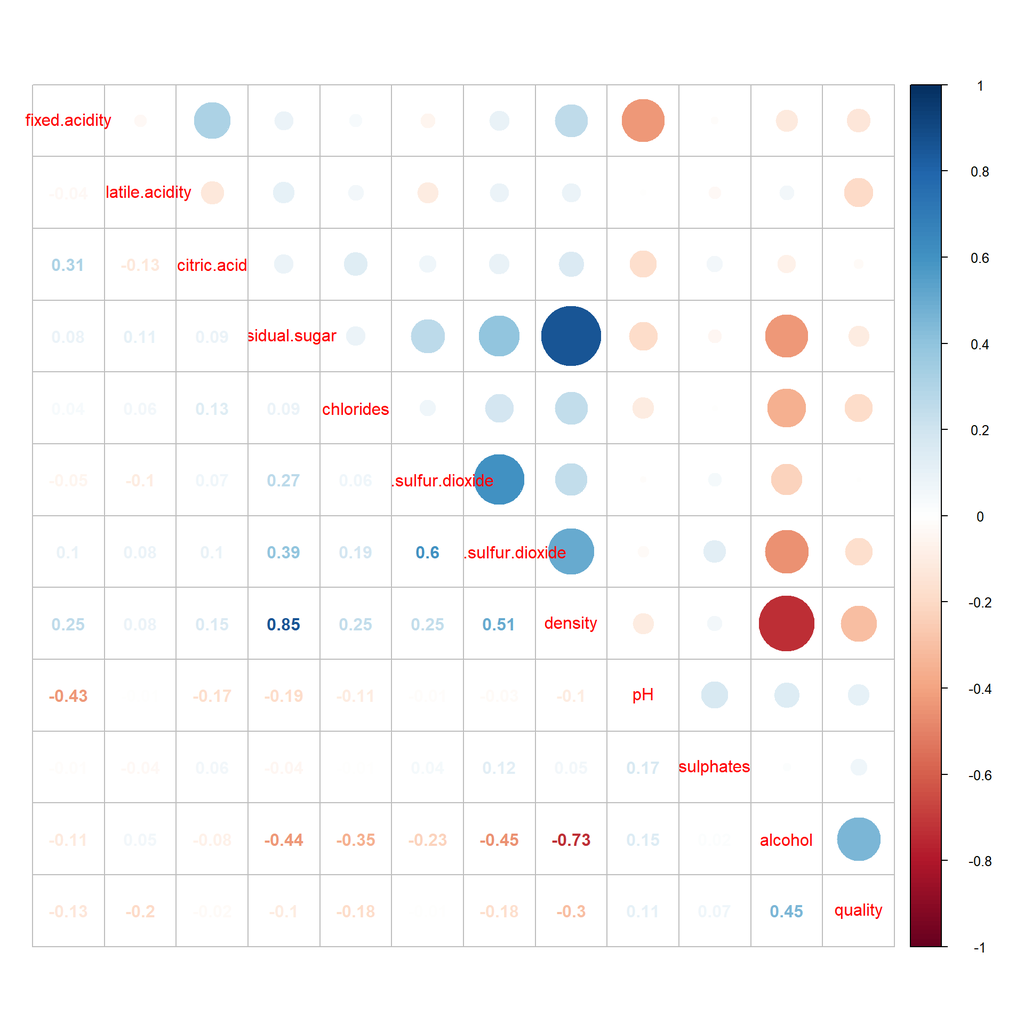

```
##                      fixed.acidity volatile.acidity citric.acid
## fixed.acidity           1.00000000     -0.036331399  0.31072880
## volatile.acidity       -0.03633140      1.000000000 -0.12576632
## citric.acid             0.31072880     -0.125766315  1.00000000
## residual.sugar          0.08464961      0.108990124  0.08670278
## chlorides               0.03912104      0.057005351  0.13318010
## free.sulfur.dioxide    -0.05071447     -0.101494202  0.06997365
## total.sulfur.dioxide    0.09541171      0.082834225  0.09660397
## density                 0.25092251      0.081489161  0.15238720
## pH                     -0.43210622     -0.009251582 -0.17098964
## sulphates              -0.01284860     -0.037084179  0.05998456
## alcohol                -0.11169885      0.051330422 -0.07979826
## quality                -0.13049672     -0.198681537 -0.02141302
##                      residual.sugar    chlorides free.sulfur.dioxide
## fixed.acidity            0.08464961  0.039121042        -0.050714474
## volatile.acidity         0.10899012  0.057005351        -0.101494202
## citric.acid              0.08670278  0.133180102         0.069973650
## residual.sugar           1.00000000  0.089051671         0.269199198
## chlorides                0.08905167  1.000000000         0.060767389
## free.sulfur.dioxide      0.26919920  0.060767389         1.000000000
## total.sulfur.dioxide     0.39388393  0.188888326         0.602817902
## density                  0.85193197  0.249584343         0.247404449
## pH                      -0.18883346 -0.106914981        -0.010084744
## sulphates               -0.04231295 -0.008515354         0.043689706
## alcohol                 -0.43807418 -0.354478252        -0.227548557
## quality                 -0.10187007 -0.182893281        -0.005955651
##                      total.sulfur.dioxide     density           pH
## fixed.acidity                  0.09541171  0.25092251 -0.432106217
## volatile.acidity               0.08283423  0.08148916 -0.009251582
## citric.acid                    0.09660397  0.15238720 -0.170989641
## residual.sugar                 0.39388393  0.85193197 -0.188833458
## chlorides                      0.18888833  0.24958434 -0.106914981
## free.sulfur.dioxide            0.60281790  0.24740445 -0.010084744
## total.sulfur.dioxide           1.00000000  0.50734078 -0.029311693
## density                        0.50734078  1.00000000 -0.101117808
## pH                            -0.02931169 -0.10111781  1.000000000
## sulphates                      0.12000196  0.05290348  0.168722574
## alcohol                       -0.45137845 -0.73310070  0.149849480
## quality                       -0.17947030 -0.30449983  0.106867586
##                         sulphates     alcohol      quality
## fixed.acidity        -0.012848596 -0.11169885 -0.130496725
## volatile.acidity     -0.037084179  0.05133042 -0.198681537
## citric.acid           0.059984560 -0.07979826 -0.021413016
## residual.sugar       -0.042312954 -0.43807418 -0.101870072
## chlorides            -0.008515354 -0.35447825 -0.182893281
## free.sulfur.dioxide   0.043689706 -0.22754856 -0.005955651
## total.sulfur.dioxide  0.120001960 -0.45137845 -0.179470298
## density               0.052903475 -0.73310070 -0.304499834
## pH                    0.168722574  0.14984948  0.106867586
## sulphates             1.000000000  0.01612091  0.066736748
## alcohol               0.016120913  1.00000000  0.450474918
## quality               0.066736748  0.45047492  1.000000000
```

Observamos um caminho em comum entre os dois tipos de vinho, em que a melhor correlação da qualidade é com o álcool e a melhor correlação do álcool é com a densidade. No entanto, a melhor correlação da densidade difere para os tipos de vinho, sendo a acidez fixa para o vinho tinto e o açucar residual para o vinho branco.

A seguir exploraremos melhor estas correlações.

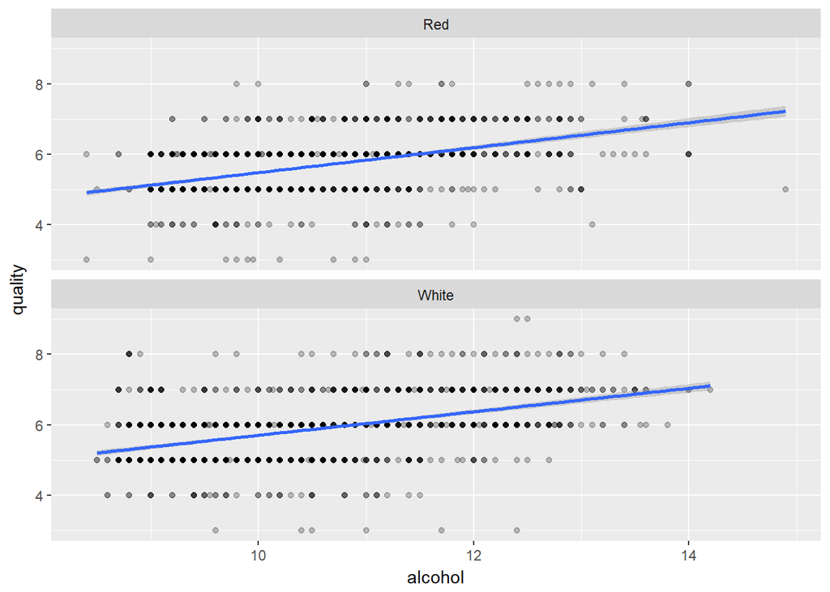

```
## Vinho Tinto:
```

```
##
## Call:
## lm(formula = quality ~ alcohol, data = subset(ws, type == "Red"))
##
## Residuals:
##     Min      1Q  Median      3Q     Max
## -2.8331 -0.4064 -0.1575  0.5225  2.5936
##
## Coefficients:
##             Estimate Std. Error t value Pr(>|t|)
## (Intercept)  1.92212    0.18137    10.6   <2e-16 ***
## alcohol      0.35554    0.01735    20.5   <2e-16 ***
## ---
## Signif. codes:  0 '***' 0.001 '**' 0.01 '*' 0.05 '.' 0.1 ' ' 1
##
## Residual standard error: 0.7101 on 1498 degrees of freedom
## Multiple R-squared:  0.219,  Adjusted R-squared:  0.2185
## F-statistic: 420.1 on 1 and 1498 DF,  p-value: < 2.2e-16
```

```
## Vinho Branco:
```

```
##
## Call:
## lm(formula = quality ~ alcohol, data = subset(ws, type == "White"))
##
## Residuals:
##     Min      1Q  Median      3Q     Max
## -3.5049 -0.5049 -0.0044  0.4961  2.6963
##
## Coefficients:
##             Estimate Std. Error t value Pr(>|t|)
## (Intercept)  2.36751    0.18031   13.13   <2e-16 ***
## alcohol      0.33366    0.01709   19.53   <2e-16 ***
## ---
## Signif. codes:  0 '***' 0.001 '**' 0.01 '*' 0.05 '.' 0.1 ' ' 1
##
## Residual standard error: 0.7937 on 1498 degrees of freedom
## Multiple R-squared:  0.2029, Adjusted R-squared:  0.2024
## F-statistic: 381.4 on 1 and 1498 DF,  p-value: < 2.2e-16
```

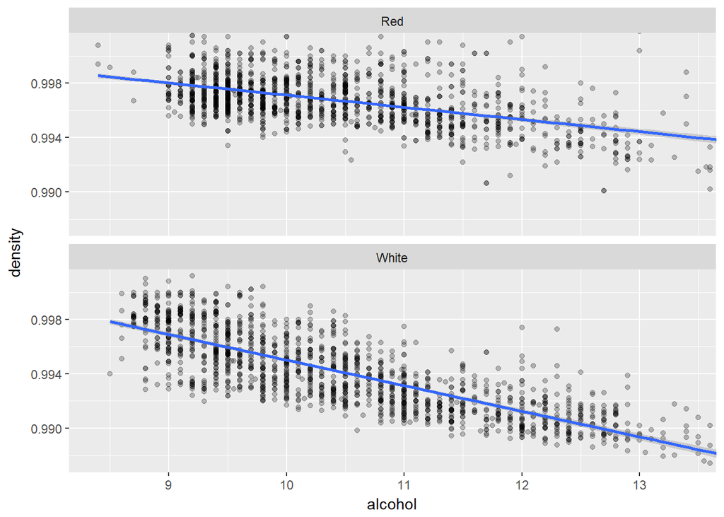

```
## Vinho Tinto:
```

```
##
## Call:
## lm(formula = density ~ alcohol, data = subset(ws, type == "Red"))
##
## Residuals:
##        Min         1Q     Median         3Q        Max
## -0.0049599 -0.0010838 -0.0002385  0.0008279  0.0073966
##
## Coefficients:
##               Estimate Std. Error t value Pr(>|t|)
## (Intercept)  1.0060893  0.0004204  2393.3   <2e-16 ***
## alcohol     -0.0008965  0.0000402   -22.3   <2e-16 ***
## ---
## Signif. codes:  0 '***' 0.001 '**' 0.01 '*' 0.05 '.' 0.1 ' ' 1
##
## Residual standard error: 0.001646 on 1498 degrees of freedom
## Multiple R-squared:  0.2492, Adjusted R-squared:  0.2487
## F-statistic: 497.3 on 1 and 1498 DF,  p-value: < 2.2e-16
```

```
## Vinho Branco:
```

```
##
## Call:
## lm(formula = density ~ alcohol, data = subset(ws, type == "White"))
##
## Residuals:
##       Min        1Q    Median        3Q       Max
## -0.004418 -0.001234 -0.000161  0.001124  0.047164
##
## Coefficients:
##               Estimate Std. Error t value Pr(>|t|)
## (Intercept)  1.014e+00  4.764e-04 2127.98   <2e-16 ***
## alcohol     -1.883e-03  4.515e-05  -41.72   <2e-16 ***
## ---
## Signif. codes:  0 '***' 0.001 '**' 0.01 '*' 0.05 '.' 0.1 ' ' 1
##
## Residual standard error: 0.002097 on 1498 degrees of freedom
## Multiple R-squared:  0.5374, Adjusted R-squared:  0.5371
## F-statistic:  1740 on 1 and 1498 DF,  p-value: < 2.2e-16
```

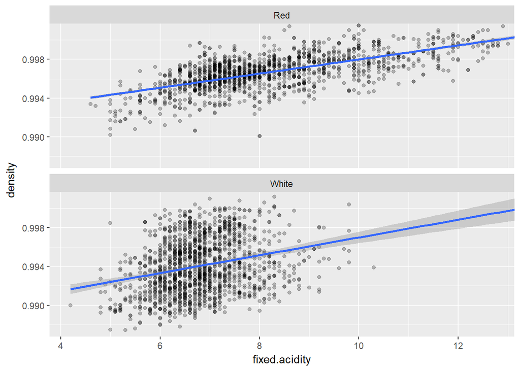

```
## Vinho Tinto:
```

```
##
## Call:
## lm(formula = density ~ fixed.acidity, data = subset(ws, type ==
##     "Red"))
##
## Residuals:
##        Min         1Q     Median         3Q        Max
## -0.0064668 -0.0007516  0.0000657  0.0009354  0.0055464
##
## Coefficients:
##                Estimate Std. Error t value Pr(>|t|)
## (Intercept)   9.907e-01  1.756e-04 5640.29   <2e-16 ***
## fixed.acidity 7.304e-04  2.068e-05   35.31   <2e-16 ***
## ---
## Signif. codes:  0 '***' 0.001 '**' 0.01 '*' 0.05 '.' 0.1 ' ' 1
##
## Residual standard error: 0.001403 on 1498 degrees of freedom
## Multiple R-squared:  0.4543, Adjusted R-squared:  0.4539
## F-statistic:  1247 on 1 and 1498 DF,  p-value: < 2.2e-16
```

```
## Vinho Branco:
```

```
##
## Call:
## lm(formula = density ~ fixed.acidity, data = subset(ws, type ==
##     "White"))
##
## Residuals:
##       Min        1Q    Median        3Q       Max
## -0.008867 -0.002193 -0.000381  0.002028  0.043994
##
## Coefficients:
##                Estimate Std. Error t value Pr(>|t|)
## (Intercept)   9.878e-01  6.312e-04 1565.09   <2e-16 ***
## fixed.acidity 9.188e-04  9.158e-05   10.03   <2e-16 ***
## ---
## Signif. codes:  0 '***' 0.001 '**' 0.01 '*' 0.05 '.' 0.1 ' ' 1
##
## Residual standard error: 0.002985 on 1498 degrees of freedom
## Multiple R-squared:  0.06296,    Adjusted R-squared:  0.06234
## F-statistic: 100.7 on 1 and 1498 DF,  p-value: < 2.2e-16
```

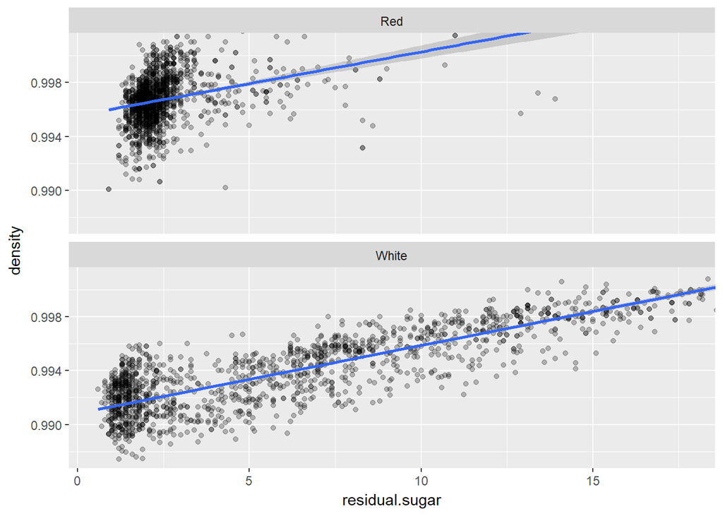

```
## Vinho Tinto:
```

```
##
## Call:
## lm(formula = density ~ residual.sugar, data = subset(ws, type ==
##     "Red"))
##
## Residuals:
##        Min         1Q     Median         3Q        Max
## -0.0073964 -0.0010453  0.0000128  0.0010800  0.0058868
##
## Coefficients:
##                 Estimate Std. Error  t value Pr(>|t|)
## (Intercept)    9.956e-01  9.432e-05 10555.02   <2e-16 ***
## residual.sugar 4.720e-04  3.251e-05    14.52   <2e-16 ***
## ---
## Signif. codes:  0 '***' 0.001 '**' 0.01 '*' 0.05 '.' 0.1 ' ' 1
##
## Residual standard error: 0.001778 on 1498 degrees of freedom
## Multiple R-squared:  0.1234, Adjusted R-squared:  0.1228
## F-statistic: 210.9 on 1 and 1498 DF,  p-value: < 2.2e-16
```

```
## Vinho Branco:
```

```
##
## Call:
## lm(formula = density ~ residual.sugar, data = subset(ws, type ==
##     "White"))
##
## Residuals:
##        Min         1Q     Median         3Q        Max
## -0.0045735 -0.0010591  0.0001475  0.0011179  0.0149417
##
## Coefficients:
##                 Estimate Std. Error  t value Pr(>|t|)
## (Intercept)    9.908e-01  6.658e-05 14881.74   <2e-16 ***
## residual.sugar 5.046e-04  8.014e-06    62.97   <2e-16 ***
## ---
## Signif. codes:  0 '***' 0.001 '**' 0.01 '*' 0.05 '.' 0.1 ' ' 1
##
## Residual standard error: 0.001615 on 1498 degrees of freedom
## Multiple R-squared:  0.7258, Adjusted R-squared:  0.7256
## F-statistic:  3965 on 1 and 1498 DF,  p-value: < 2.2e-16
```

Podemos observar uma tendência linear nos gráficos de dispersão acima, com exceção da relação entre densidade e acidez fixa para os vinhos brancos e da relação densidade e açúcar residual para os vinhos tintos.

Apesar de apresentarem pouca correlação com a qualidade, verificaremos a distribuição destas propriedades químicas utilizadado nossa classificação de qualidade personalizada.

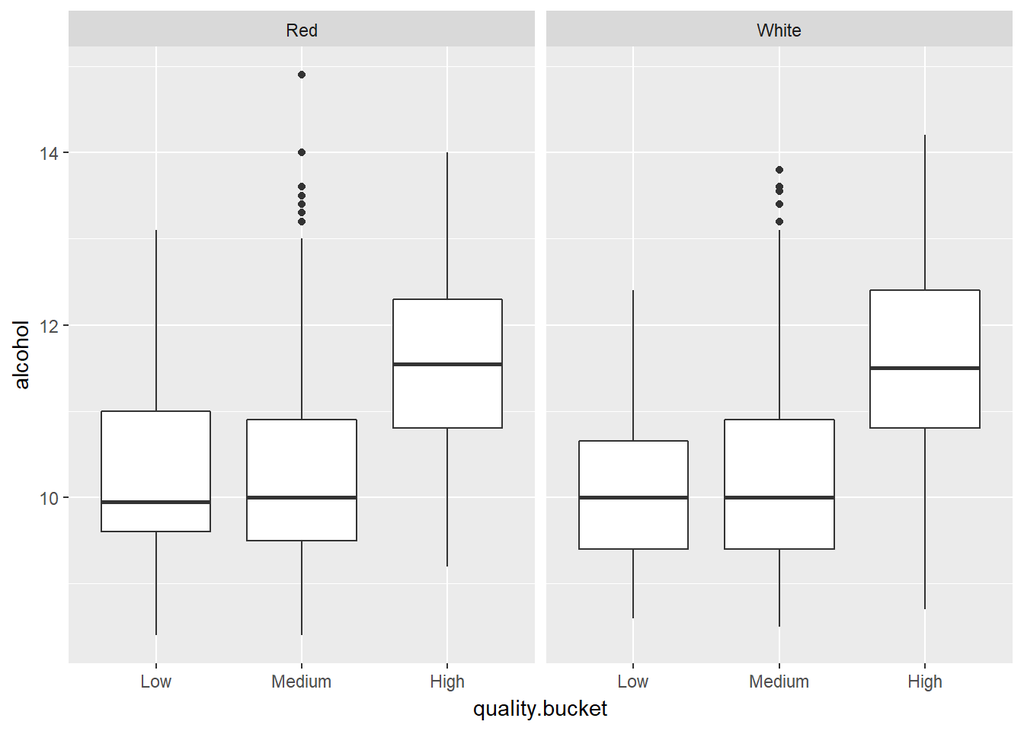

```
## Vinho Tinto
```

```
## quality.bucket: Low
##    Min. 1st Qu.  Median    Mean 3rd Qu.    Max.
##    8.40    9.60    9.95   10.21   11.00   13.10
## --------------------------------------------------------
## quality.bucket: Medium
##    Min. 1st Qu.  Median    Mean 3rd Qu.    Max.
##    8.40    9.50   10.00   10.24   10.90   14.90
## --------------------------------------------------------
## quality.bucket: High
##    Min. 1st Qu.  Median    Mean 3rd Qu.    Max.
##    9.20   10.80   11.55   11.51   12.30   14.00
```

```
## Vinho Branco
```

```
## quality.bucket: Low
##    Min. 1st Qu.  Median    Mean 3rd Qu.    Max.
##    8.60    9.40   10.00   10.06   10.65   12.40
## --------------------------------------------------------
## quality.bucket: Medium
##    Min. 1st Qu.  Median    Mean 3rd Qu.    Max.
##    8.50    9.40   10.00   10.23   10.90   13.80
## --------------------------------------------------------
## quality.bucket: High
##    Min. 1st Qu.  Median    Mean 3rd Qu.    Max.
##    8.70   10.80   11.50   11.42   12.40   14.20
```

Para ambos os tipos de vinho, aqueles que classificados como de alta qualidade apresentam, em média, mais álcool que os vinhos de qualidade média ou baixa.

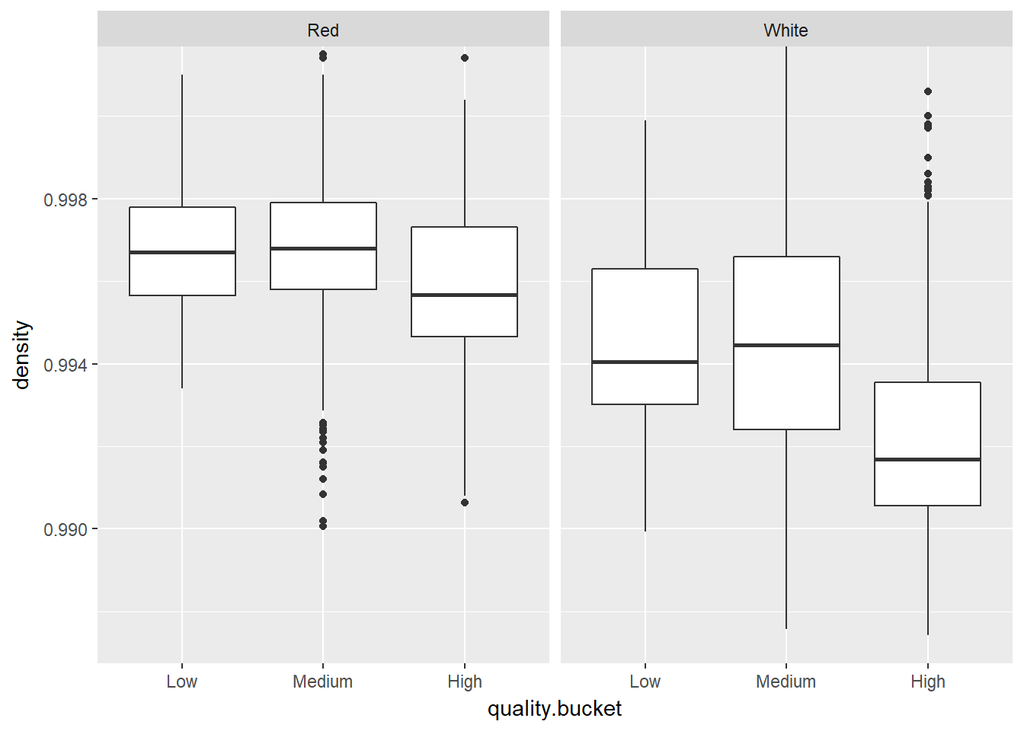

```
## Vinho Tinto
```

```
## quality.bucket: Low
##    Min. 1st Qu.  Median    Mean 3rd Qu.    Max.
##  0.9934  0.9957  0.9967  0.9968  0.9978  1.0010
## --------------------------------------------------------
## quality.bucket: Medium
##    Min. 1st Qu.  Median    Mean 3rd Qu.    Max.
##  0.9901  0.9958  0.9968  0.9969  0.9979  1.0037
## --------------------------------------------------------
## quality.bucket: High
##    Min. 1st Qu.  Median    Mean 3rd Qu.    Max.
##  0.9906  0.9947  0.9957  0.9960  0.9973  1.0032
```

```
## Vinho Branco
```

```
## quality.bucket: Low
##    Min. 1st Qu.  Median    Mean 3rd Qu.    Max.
##  0.9899  0.9930  0.9940  0.9946  0.9963  0.9999
## --------------------------------------------------------
## quality.bucket: Medium
##    Min. 1st Qu.  Median    Mean 3rd Qu.    Max.
##  0.9876  0.9924  0.9944  0.9946  0.9966  1.0390
## --------------------------------------------------------
## quality.bucket: High
##    Min. 1st Qu.  Median    Mean 3rd Qu.    Max.
##  0.9874  0.9906  0.9917  0.9924  0.9935  1.0006
```

Como existe uma correlação negativa entre álcool e densidade, é de se esperar que encontremos uma distribuição semelhante à anterior, em que os vinho classificados como de alta qualidade apresentam, em média, menos densidade que os vinhos de qualidade média ou baixa.

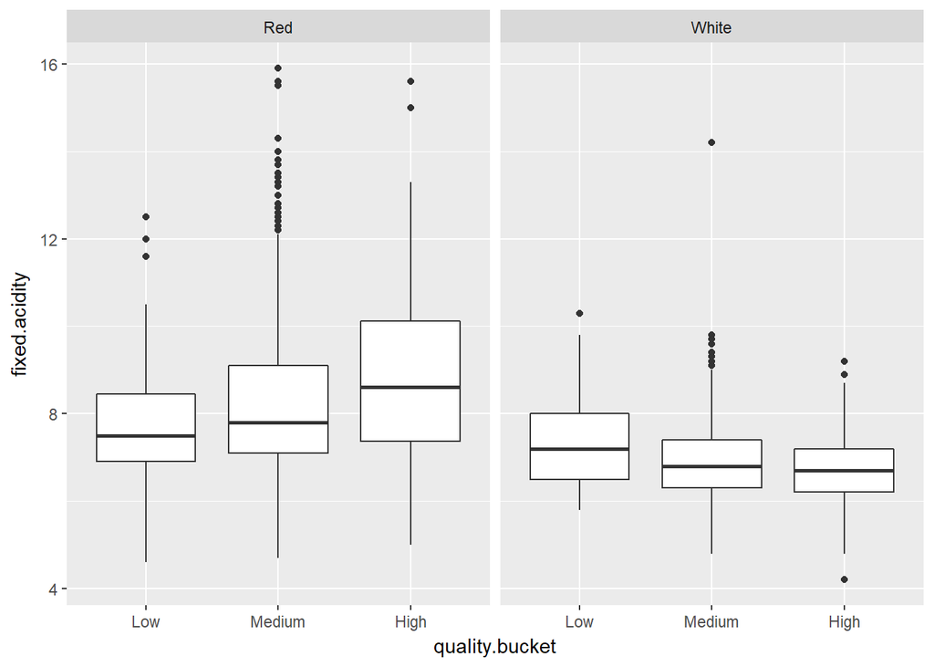

```
## Vinho Tinto
```

```
## quality.bucket: Low
##    Min. 1st Qu.  Median    Mean 3rd Qu.    Max.
##   4.600   6.900   7.500   7.934   8.450  12.500
## --------------------------------------------------------
## quality.bucket: Medium
##    Min. 1st Qu.  Median    Mean 3rd Qu.    Max.
##   4.700   7.100   7.800   8.248   9.100  15.900
## --------------------------------------------------------
## quality.bucket: High
##    Min. 1st Qu.  Median    Mean 3rd Qu.    Max.
##   5.000   7.375   8.600   8.831  10.125  15.600
```

```
## Vinho Branco
```

```
## quality.bucket: Low
##    Min. 1st Qu.  Median    Mean 3rd Qu.    Max.
##   5.800   6.500   7.200   7.309   8.000  10.300
## --------------------------------------------------------
## quality.bucket: Medium
##    Min. 1st Qu.  Median    Mean 3rd Qu.    Max.
##    4.80    6.30    6.80    6.86    7.40   14.20
## --------------------------------------------------------
## quality.bucket: High
##    Min. 1st Qu.  Median    Mean 3rd Qu.    Max.
##   4.200   6.200   6.700   6.693   7.200   9.200
```

Para os vinhos tintos, quanto maior a média da acidez fixa, maior é a qualidade. Já para os vinhos brancos, parece haver uma discreta relação inversa, quanto menor a média de acidez fixa, maior a qualidade.

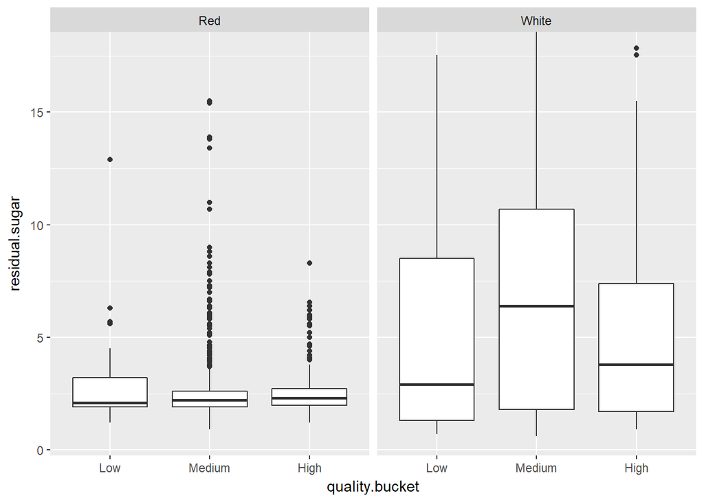

```
## Vinho Tinto
```

```
## quality.bucket: Low
##    Min. 1st Qu.  Median    Mean 3rd Qu.    Max.
##   1.200   1.900   2.100   2.735   3.200  12.900
## --------------------------------------------------------
## quality.bucket: Medium
##    Min. 1st Qu.  Median    Mean 3rd Qu.    Max.
##   0.900   1.900   2.200   2.507   2.600  15.500
## --------------------------------------------------------
## quality.bucket: High
##    Min. 1st Qu.  Median    Mean 3rd Qu.    Max.
##   1.200   1.975   2.300   2.654   2.725   8.300
```

```
## Vinho Branco
```

```
## quality.bucket: Low
##    Min. 1st Qu.  Median    Mean 3rd Qu.    Max.
##   0.700   1.300   2.900   5.196   8.500  17.550
## --------------------------------------------------------
## quality.bucket: Medium
##    Min. 1st Qu.  Median    Mean 3rd Qu.    Max.
##   0.600   1.800   6.400   6.926  10.700  65.800
## --------------------------------------------------------
## quality.bucket: High
##    Min. 1st Qu.  Median    Mean 3rd Qu.    Max.
##   0.900   1.700   3.800   5.154   7.400  17.850
```

Para o açúcar residual, não parece haver uma relação linear com a qualidade do vinho branco. A qualidade parece estar associada à “doçura” certa, não podendo ser pouco doce nem muito doce. Já para o vinho tinto, a média de açúcar residual mantém a mesma média para qualquer classificação de qualidade.

### 5. ANÁLISE BIVARIADA

#### 5.1 Discuta sobre alguns dos relacionamentos observados nesta parte da investigação. Como os atributos de interesse variaram no conjunto de dados?

Nesta investigação conseguimos definir melhor os atributos de interesse, em que o percentual alcóolico do vinho apresentou maior correlação com a qualidade, tanto para os tintos quanto para os brancos.

Porém, mesmo sendo a propriedade de melhor correlação, o álcool explica apenas 22% da qualidade dos vinhos tintos (R^2 = 0,2185) e 20% dos vinhos brancos (R^2 = 0,2024).

Ao classificar as notas dos especialistas em três grupos, podemos observar que os vinhos considerados de alta qualidade possuem teor alcóolico maior que os de baixa e média qualidade, possuindo em sua maioria entre 11% e 12% de álcool.

#### 5.2 Você observou algum relacionamento interessante entre os outros atributos (os que não são de interesse)?

Seguindo as correlações do álcool, a densidade apresentou o melhor coeficiente para os dois tipos de vinho. No entanto, seguindo as correlações da densidade, encontramos uma bifurcação por tipo de vinho, sendo a acidez fixa a melhor correlação para o vinho tinto e o açúcar residual a melhor correlação para o vinho branco.

#### 5.3 Qual foi o relacionamento mais forte encontrado?

O relacionamento mais forte encontrado foi entre densidade e açúcar residual nos vinhos brancos (r = 0,852). No entanto, estas propriedades possuem relações fracas com a qualidade.

### 6. SEÇÃO DE GRÁFICOS MULTIVARIADOS

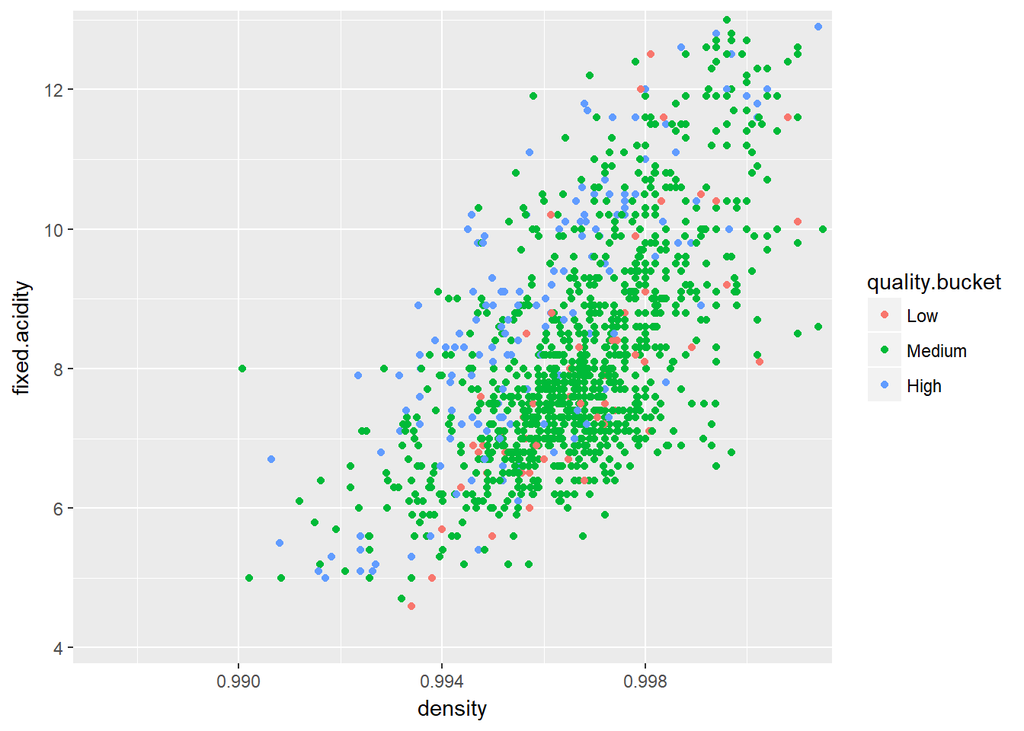

```
## Correlação entre acidez fixa e densidade de tintos de alta qualidade:
```

```
##
## Call:
## lm(formula = density ~ fixed.acidity, data = subset(ws, type ==
##     "Red" & quality.bucket == "High"))
##
## Residuals:
##        Min         1Q     Median         3Q        Max
## -0.0035158 -0.0010179 -0.0001120  0.0007469  0.0032820
##
## Coefficients:
##                Estimate Std. Error t value Pr(>|t|)
## (Intercept)   9.883e-01  4.382e-04 2255.44   <2e-16 ***
## fixed.acidity 8.747e-04  4.834e-05   18.09   <2e-16 ***
## ---
## Signif. codes:  0 '***' 0.001 '**' 0.01 '*' 0.05 '.' 0.1 ' ' 1
##
## Residual standard error: 0.001368 on 190 degrees of freedom
## Multiple R-squared:  0.6328, Adjusted R-squared:  0.6308
## F-statistic: 327.4 on 1 and 190 DF,  p-value: < 2.2e-16
```

```
## Correlação entre acidez fixa e densidade de tintos de média qualidade:
```

```
##
## Call:
## lm(formula = density ~ fixed.acidity, data = subset(ws, type ==
##     "Red" & quality.bucket == "Medium"))
##
## Residuals:
##        Min         1Q     Median         3Q        Max
## -0.0066259 -0.0006807  0.0000104  0.0008742  0.0053788
##
## Coefficients:
##                Estimate Std. Error t value Pr(>|t|)
## (Intercept)   9.908e-01  1.881e-04 5268.52   <2e-16 ***
## fixed.acidity 7.342e-04  2.234e-05   32.87   <2e-16 ***
## ---
## Signif. codes:  0 '***' 0.001 '**' 0.01 '*' 0.05 '.' 0.1 ' ' 1
##
## Residual standard error: 0.001335 on 1247 degrees of freedom
## Multiple R-squared:  0.4642, Adjusted R-squared:  0.4638
## F-statistic:  1080 on 1 and 1247 DF,  p-value: < 2.2e-16
```

```
## Correlação entre acidez fixa e densidade de tintos de baixa qualidade:
```

```
##
## Call:
## lm(formula = density ~ fixed.acidity, data = subset(ws, type ==
##     "Red" & quality.bucket == "Low"))
##
## Residuals:
##        Min         1Q     Median         3Q        Max
## -0.0022946 -0.0008004 -0.0000099  0.0006992  0.0033699
##
## Coefficients:
##                Estimate Std. Error  t value Pr(>|t|)
## (Intercept)   9.909e-01  7.263e-04 1364.202  < 2e-16 ***
## fixed.acidity 7.403e-04  8.961e-05    8.261 2.53e-11 ***
## ---
## Signif. codes:  0 '***' 0.001 '**' 0.01 '*' 0.05 '.' 0.1 ' ' 1
##
## Residual standard error: 0.001143 on 57 degrees of freedom
## Multiple R-squared:  0.5449, Adjusted R-squared:  0.5369
## F-statistic: 68.25 on 1 and 57 DF,  p-value: 2.535e-11
```

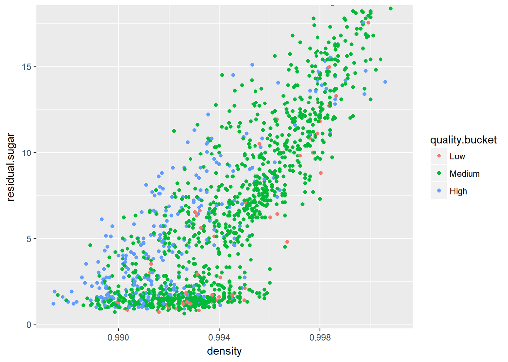

```
## Correlação entre açúcar residual e densidade de brancos de alta qualidade:
```

```
##
## Call:
## lm(formula = density ~ residual.sugar, data = subset(ws, type ==
##     "White" & quality.bucket == "High"))
##
## Residuals:
##        Min         1Q     Median         3Q        Max
## -0.0035572 -0.0010648 -0.0000289  0.0010611  0.0041859
##
## Coefficients:
##                 Estimate Std. Error t value Pr(>|t|)
## (Intercept)    9.896e-01  1.359e-04 7282.59   <2e-16 ***
## residual.sugar 5.458e-04  2.054e-05   26.57   <2e-16 ***
## ---
## Signif. codes:  0 '***' 0.001 '**' 0.01 '*' 0.05 '.' 0.1 ' ' 1
##
## Residual standard error: 0.001538 on 324 degrees of freedom
## Multiple R-squared:  0.6854, Adjusted R-squared:  0.6844
## F-statistic: 705.9 on 1 and 324 DF,  p-value: < 2.2e-16
```

```
## Correlação entre açúcar residual e densidade de brancos de média qualidade:
```

```
##
## Call:
## lm(formula = density ~ residual.sugar, data = subset(ws, type ==
##     "White" & quality.bucket == "Medium"))
##
## Residuals:
##        Min         1Q     Median         3Q        Max
## -0.0045647 -0.0008572  0.0001281  0.0009624  0.0158584
##
## Coefficients:
##                 Estimate Std. Error  t value Pr(>|t|)
## (Intercept)    9.912e-01  7.278e-05 13619.72   <2e-16 ***
## residual.sugar 4.848e-04  8.271e-06    58.61   <2e-16 ***
## ---
## Signif. codes:  0 '***' 0.001 '**' 0.01 '*' 0.05 '.' 0.1 ' ' 1
##
## Residual standard error: 0.001502 on 1117 degrees of freedom
## Multiple R-squared:  0.7546, Adjusted R-squared:  0.7544
## F-statistic:  3435 on 1 and 1117 DF,  p-value: < 2.2e-16
```

```
## Correlação entre açúcar residual e densidade de brancos de baixa qualidade:
```

```
##
## Call:
## lm(formula = density ~ residual.sugar, data = subset(ws, type ==
##     "White" & quality.bucket == "Low"))
##
## Residuals:
##        Min         1Q     Median         3Q        Max
## -0.0029352 -0.0007512  0.0002003  0.0009756  0.0022847
##
## Coefficients:
##                 Estimate Std. Error t value Pr(>|t|)
## (Intercept)    9.923e-01  2.646e-04 3750.94  < 2e-16 ***
## residual.sugar 4.366e-04  3.816e-05   11.44 6.17e-16 ***
## ---
## Signif. codes:  0 '***' 0.001 '**' 0.01 '*' 0.05 '.' 0.1 ' ' 1
##
## Residual standard error: 0.001299 on 53 degrees of freedom
## Multiple R-squared:  0.7118, Adjusted R-squared:  0.7064
## F-statistic: 130.9 on 1 and 53 DF,  p-value: 6.172e-16
```

### 7. ANÁLISE MULTIVARIADA

#### 7.1 Discuta sobre os relacionamentos observados nesta parte da investigação. Quais atributos que fortaleceram os demais na observação das variáveis de interesse?

Acima, exploramos as relações entre qualidade, densidade e os atributos de cada tipo de vinho que melhor se relacionam com este último. A classificação da qualidade nos auxilia a visualizar onde se encontram as distribuições dos vinhos de alta qualidade.

#### 7.2 Interações surpreendentes e/ou interessantes foram encontradas entre os atributos?

Os vinhos de qualidade alta apresentam uma faixa de equilibrio entre acidez fixa e densidade para os vinhos tintos e entre açúcar residual e densidade para os vinhos brancos. Porém, é visualmente difícil identificar uma faixa que diferencie os vinhos de qualidade média dos de qualidade baixa.

### 8. GRÁFICOS FINAIS E SUMÁRIO

#### 8.1 Primeiro gráfico

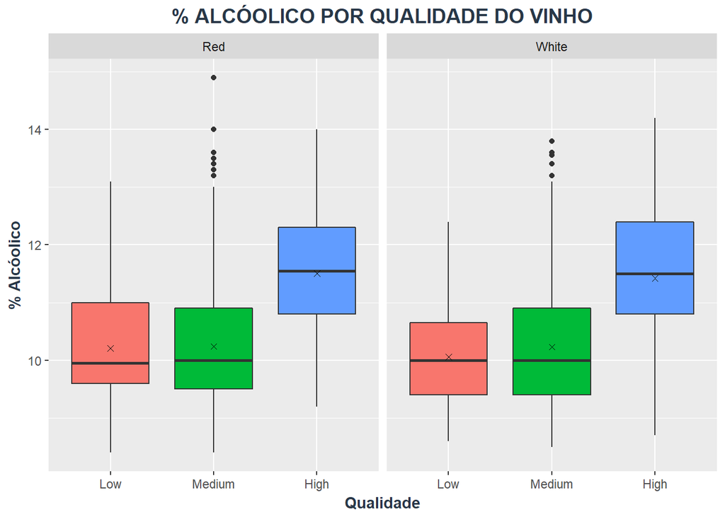

#### 8.2 Descrição do primeiro gráfico

O volume alcóolico é a propriedade química que mais se relaciona com a qualidade. No gráfico de caixa acima este relacionamento é evidenciado ao mostrar que a média e mediana do percentual alcóolico é maior para os vinhos de alta qualidade, tanto para os vinhos tintos quanto brancos. Enquanto a média do volume alcóolico nos vinhos de baixa e média qualidade é por volta de 10%, nos vinhos de alta qualidade essa média sobe para 11,5%.

#### 8.3 Segundo gráfico

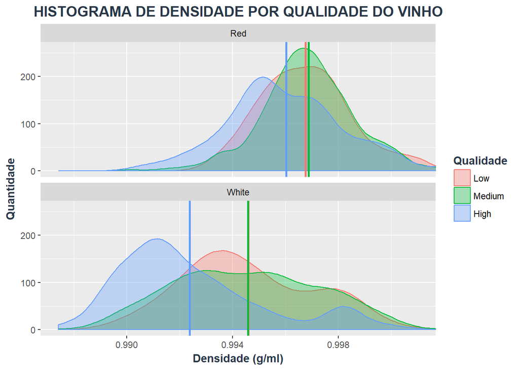